# Week 3: Logistic regression

```r
date()
```

```
## [1] "Fri Nov 19 18:09:32 2021"
```

## 1) Introduction and exploration of the data

The data explores student achievement in maths and Portuguese language at the secondary education level in two Portuguese schools. The data was downloaded from [here](https://archive.ics.uci.edu/ml/datasets/Student+Performance) and modified for this exercise.

```r
# import the data
students_poma <- read.table("./Data/student-portmath.txt", sep = "\t")

# dimensions
dim(students_poma)
```

```
## [1] 370  51
```

```r
# variable names
names(students_poma)
```

```
##  [1] "school"     "sex"        "age"        "address"    "famsize"
##  [6] "Pstatus"    "Medu"       "Fedu"       "Mjob"       "Fjob"
## [11] "reason"     "guardian"   "traveltime" "studytime"  "schoolsup"
## [16] "famsup"     "activities" "nursery"    "higher"     "internet"
## [21] "romantic"   "famrel"     "freetime"   "goout"      "Dalc"
## [26] "Walc"       "health"     "n"          "id.p"       "id.m"
## [31] "failures"   "paid"       "absences"   "G1"         "G2"
## [36] "G3"         "failures.p" "paid.p"     "absences.p" "G1.p"
## [41] "G2.p"       "G3.p"       "failures.m" "paid.m"     "absences.m"
## [46] "G1.m"       "G2.m"       "G3.m"       "alc_use"    "high_use"
## [51] "cid"
```

The data has 370 observations by 51 variables, including binary and numeric variables. Find more information about the variables [here](https://archive.ics.uci.edu/ml/datasets/Student+Performance). Separate data sets for maths and Portuguese language classes were merged and at the same time a number of variables were added to the data. Variables with suffix *.p* are specific for performance in Portuguese language, and with suffix *.m* in maths. Variable *alc_use* is the average of *Dalc* and *Walc* and variable *high_use* is ‘TRUE’ if *alc_use* is higher than 2.

We will to study the relationship between high/low alcohol consumption and some of the variables. Let’s choose four variables for the purpose: *sex, absences, failures* and *G3*. I’m hypothesizing that high alcohol consumption leads to increased occasions of absences and failures in the classes and lower grades in the final exam (*G3*). Sex might also have an impact on alcohol consumption, and I’m guessing that males show more often high alcohol consumption compared to females.

Let’s explore the distributions and relationships between these four variables and high/low alcohol consumption next.

```r
# load the libraries
library(ggplot2)
library(GGally)
library(ggpubr)

# make a new data frame including only the variables you're interested in
my_var <- c("high_use", "sex", "failures", "absences", "G3")
poma_4var <- students_poma[,my_var]

# high/low alcohol consumption by sex
table(high_use = poma_4var$high_use, sex = poma_4var$sex)
```

```
##         sex
## high_use   F   M
##    FALSE 154 105
##    TRUE   41  70
```

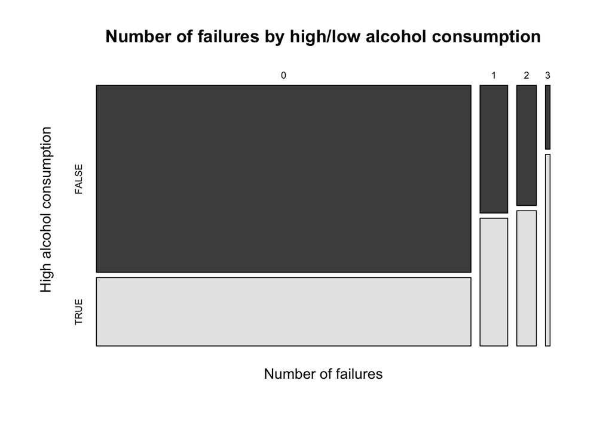

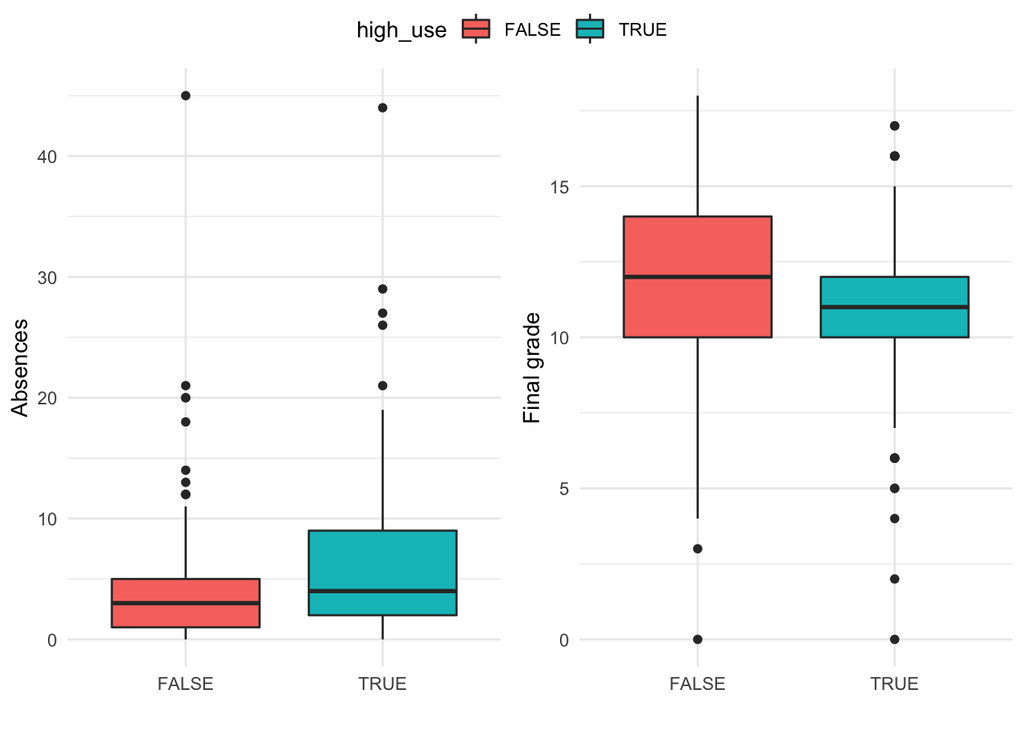

```r
# fraction failures by student high/low alcohol consumption
mosaicplot(table(poma_4var$failures, poma_4var$high_use), main = "Number of failures by high/low alcohol consumption", xlab = "Number of failures", ylab = "High alcohol consumption", color = T)

# plot number of absences by high/low alcohol consumption
p1 <- ggplot(poma_4var, aes(x = high_use, y = absences, fill = high_use)) +
            geom_boxplot() + theme_minimal() + xlab("") + ylab("Absences")

# plot final grade by high/low alcohol consumption
p2 <- ggplot(poma_4var, aes(x = high_use, y = G3, fill = high_use)) +
            geom_boxplot() + theme_minimal() + xlab("") + ylab("Final grade")

# plot the box plots together
ggarrange(p1, p2, ncol = 2, common.legend = T)
```

High alcohol consumption is more common in males compared to females. The frequency of failures also appears greater in proportion with high alcohol consumption compared to low. The number of absences is higher more often in students who consume high amounts of alcohol compared to the students who consume low amounts. Most of the low alcohol consumption students have been absent less than five times, when for most of the high alcohol consumption student this is less than 10. Finally, low alcohol consuming students achieve more often higher grades from the final exam compared to the high alcohol consuming students. After exploring the data, the hypothesis of high alcohol consumption leading to higher number of failures and absences and eventually lower final grades seems to hold, but the significance of this relationship is yet to be studied.

## 2) Logistic regression

We will use logistic regression to statistically explore the relationship between *high/low alcohol consumption* and *sex, absences, failures* and *G3 (final grade)*.

```r
# let's first change variable 'sex' from character to factor
poma_4var$sex <- as.factor(poma_4var$sex)

# next compute the logistic regression model
M1 <- glm(high_use ~ sex + failures + absences + G3, data = poma_4var, family = "binomial")

# model summary
summary(M1)
```

```
##
## Call:
## glm(formula = high_use ~ sex + failures + absences + G3, family = "binomial",
##     data = poma_4var)
##
## Deviance Residuals:
##     Min       1Q   Median       3Q      Max
## -2.1561  -0.8429  -0.5872   1.0033   2.1393
##
## Coefficients:
##             Estimate Std. Error z value Pr(>|z|)
## (Intercept) -1.38733    0.51617  -2.688  0.00719 **
## sexM         1.00870    0.24798   4.068 4.75e-05 ***
## failures     0.50382    0.22018   2.288  0.02213 *
## absences     0.09058    0.02322   3.901 9.56e-05 ***
## G3          -0.04671    0.03948  -1.183  0.23671
## ---
## Signif. codes:  0 '***' 0.001 '**' 0.01 '*' 0.05 '.' 0.1 ' ' 1
##
## (Dispersion parameter for binomial family taken to be 1)
##
##     Null deviance: 452.04  on 369  degrees of freedom
## Residual deviance: 405.59  on 365  degrees of freedom
## AIC: 415.59
##
## Number of Fisher Scoring iterations: 4
```

```r
# compute odds ratios and confident intervals
OR <- coef(M1) %>% exp
CI <- confint(M1) %>% exp
cbind(OR, CI) # prints out the ORs with their CIs
```

```
##                    OR      2.5 %    97.5 %
## (Intercept) 0.2497422 0.08880747 0.6760545
## sexM        2.7420380 1.69666006 4.4943946
## failures    1.6550376 1.08094265 2.5808643
## absences    1.0948038 1.04844539 1.1486025
## G3          0.9543647 0.88291082 1.0311936
```

The logistic regression model suggests that males have significantly higher probability for high alcohol consumption compared to females. Students showing high alcohol consumption are also more likely to fail in the classes and be absent from the school. These results were significant. However, high alcohol consumption is not affecting the final grade. The odds ratio for sex indicates a student showing high alcohol consumption is 2.7 times more likely to be male. The odds ratios indicate that a person is 1.65 times more likely to fail a class and 1.1 times more likely to be absent if their alcohol consumption is high.

Let’s modify the model so that it includes only the variables that showed statistically significant relationship with high/low alcohol consumption. Then we will explore the predictive power of this model.

```r
# make a new model
M2 <- glm(high_use ~ sex + failures + absences, data = poma_4var, family = "binomial")

summary(M2)
```

```
##
## Call:
## glm(formula = high_use ~ sex + failures + absences, family = "binomial",
##     data = poma_4var)
##
## Deviance Residuals:
##     Min       1Q   Median       3Q      Max
## -2.1550  -0.8430  -0.5889   1.0328   2.0374
##
## Coefficients:
##             Estimate Std. Error z value Pr(>|z|)
## (Intercept) -1.94150    0.23129  -8.394  < 2e-16 ***
## sexM         0.99731    0.24725   4.034 5.49e-05 ***
## failures     0.59759    0.20698   2.887  0.00389 **
## absences     0.09245    0.02323   3.979 6.91e-05 ***
## ---
## Signif. codes:  0 '***' 0.001 '**' 0.01 '*' 0.05 '.' 0.1 ' ' 1
##
## (Dispersion parameter for binomial family taken to be 1)
##
##     Null deviance: 452.04  on 369  degrees of freedom
## Residual deviance: 406.99  on 366  degrees of freedom
## AIC: 414.99
##
## Number of Fisher Scoring iterations: 4
```

```r
# predictive model
# predict the probability of high alcohol consumption
probs <- predict(M2, type = "response")

# add the predicted probabilities to your data set
library(dplyr)
poma_4var <- mutate(poma_4var, probability = probs)

# use the probabilities to predict high alcohol consumption
poma_4var <- mutate(poma_4var, predictions = probability > 0.5)

# print predictions vs actual values
table(high_use = poma_4var$high_use, prediction = poma_4var$prediction)
```

```
##         prediction
## high_use FALSE TRUE
##    FALSE   252    7
##    TRUE     78   33
```

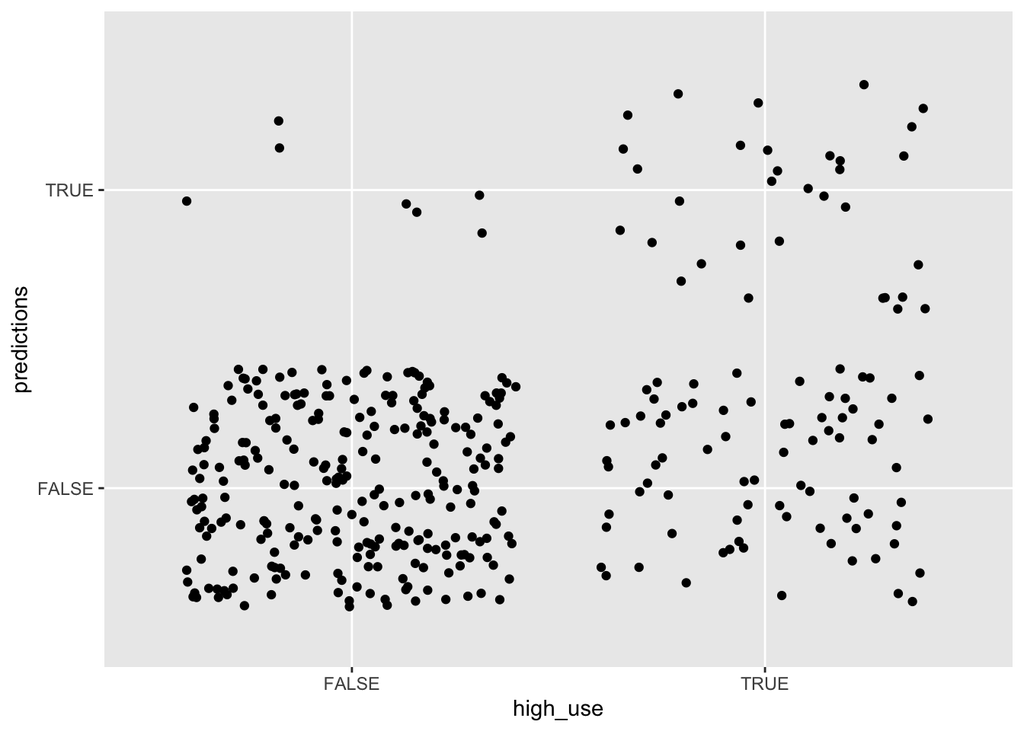

```r
# show the same in a plot
p3 <- ggplot(poma_4var, aes(x = high_use, y = predictions))
p3 + geom_point(position = "jitter")
```

```r
# compute the proportion of inaccurately classified individuals
# define a loss function (mean prediction error)
loss_func <- function(class, prob) {
  n_wrong <- abs(class - prob) > 0.5
  mean(n_wrong)
}

# call loss_func to compute the average number of wrong predictions in the data
loss_func(class = poma_4var$high_use, prob = 0)
```

```
## [1] 0.3
```